# Project 2: Data Mining, Classification, Prediction

### Cluster Analysis

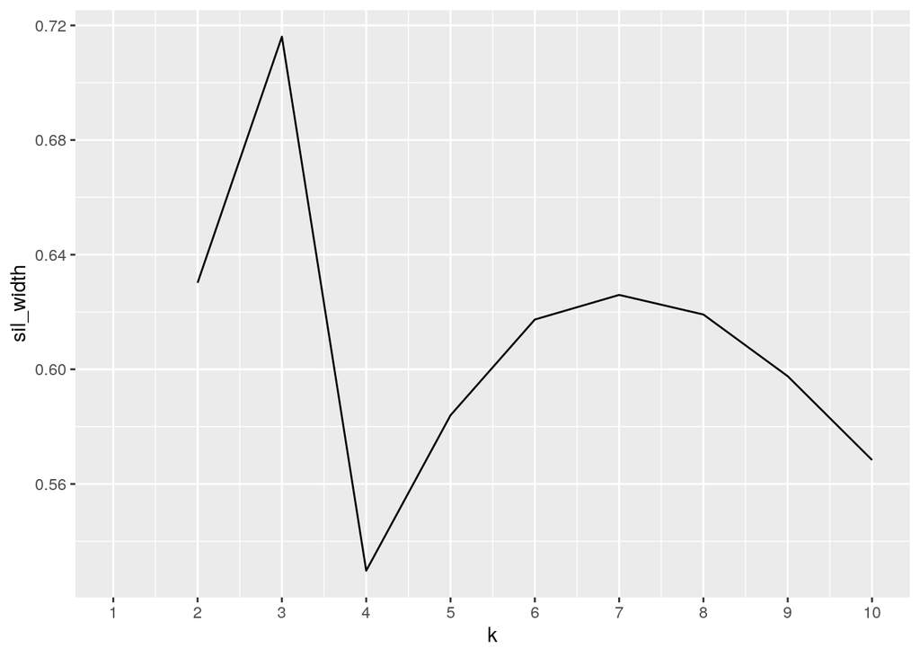

```r
library(cluster)
# clustering code here Partioning around Medoids (PAM) is a
# robust alternative to k-means - better to use this one in
# practice, # using actual data points

pam_dat <- airline_safety1 %>% dplyr::select(avail_seat_km_per_week,
    incidents_00_14, fatal_accidents_00_14, fatalities_00_14)
sil_width <- vector()
for (i in 2:10) {
    pam_fit <- pam(pam_dat, k = i)
    sil_width[i] <- pam_fit$silinfo$avg.width
}
ggplot() + geom_line(aes(x = 1:10, y = sil_width)) + scale_x_continuous(name = "k",
    breaks = 1:10)
```

```r
set.seed(322)
pam1 <- pam_dat %>% pam(k = 3)
pam1
```

```
## Medoids:
##      ID avail_seat_km_per_week incidents_00_14 fatal_accidents_00_14
## [1,] 21              557699891               4                     1
## [2,] 38             1917428984               5                     0
## [3,] 20             6525658894              24                     2
##      fatalities_00_14
## [1,]               14
## [2,]                0
## [3,]               51
## Clustering vector:
##  [1] 1 1 1 1 2 2 1 1 1 1 2 3 1 1 2 2 1 1 1 3 1 1 1 1 1 1 1 1 2 1 2 2 1 2 1 1 1 2
## [39] 1 1 1 2 1 2 1 1 1 2 1 2 2 3 2 1 1 1
## Objective function:
##     build      swap
## 384237652 324069831
##
## Available components:
##  [1] "medoids"    "id.med"     "clustering" "objective"  "isolation"
##  [6] "clusinfo"   "silinfo"    "diss"       "call"       "data"
```

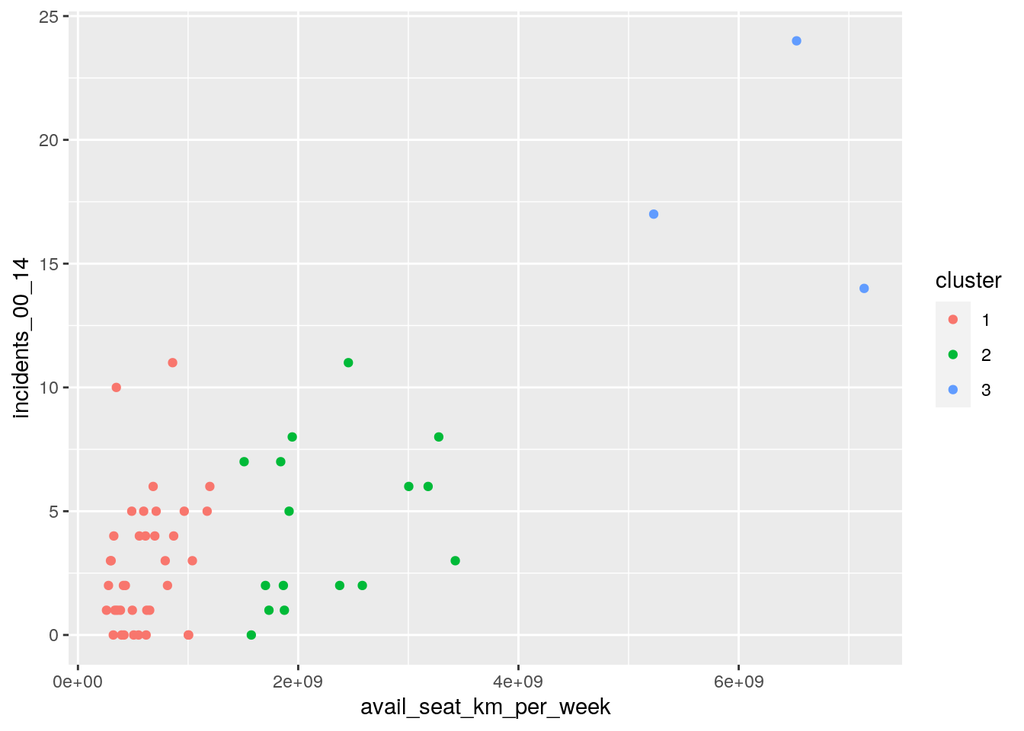

```r
clust_dat <- pam_dat %>% mutate(cluster = as.factor(pam1$clustering))

## gg-plot
pamclust <- clust_dat %>% mutate(cluster = as.factor(pam1$clustering))
pamclust %>% ggplot(aes(avail_seat_km_per_week, incidents_00_14,
    color = cluster)) + geom_point()
```

```r
pam1$silinfo$avg.width  # Average Silhouette Width # Strong structure: 0.71 - 1.0
```

```
## [1] 0.7160523
```

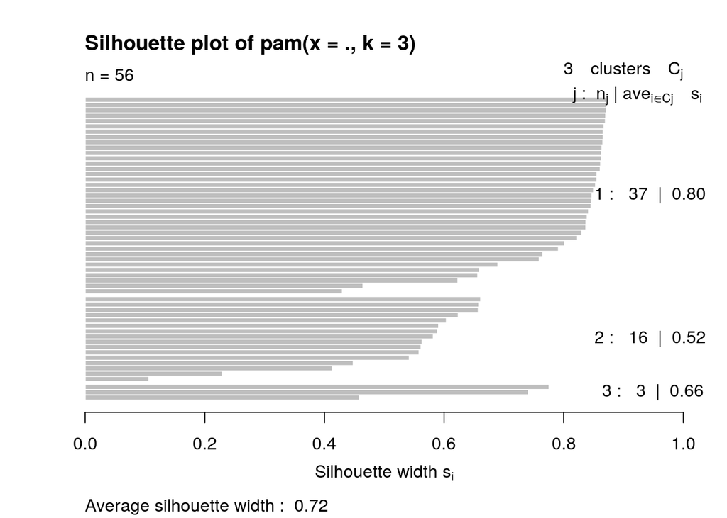

```r
# Interpreting Average Silhouette Width
plot(pam1, which = 2)
```

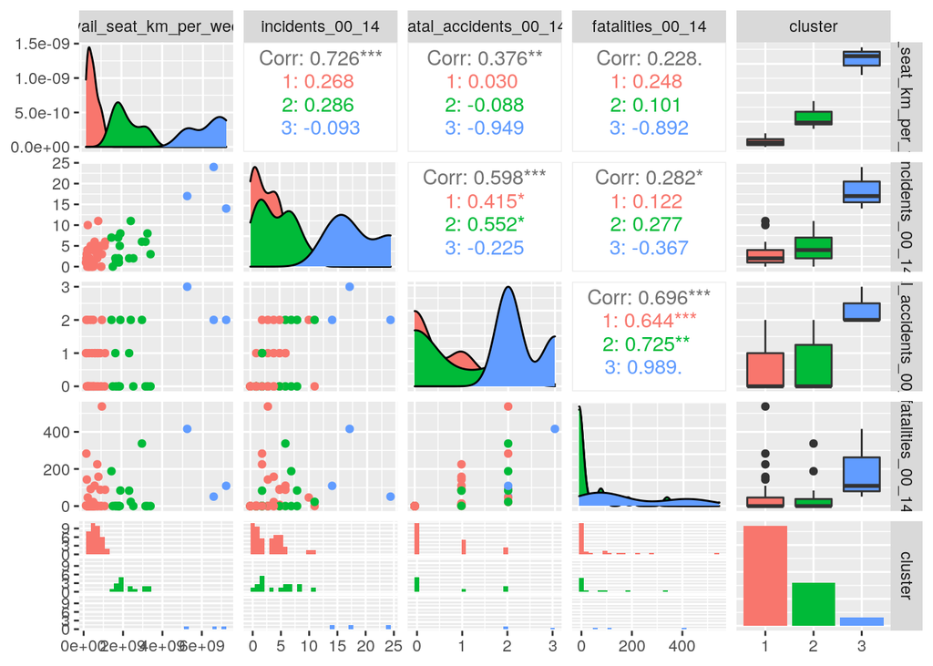

```r
library(GGally)
ggpairs(clust_dat, aes(color = cluster))
```

For the PAM clustering model, all 4 of my numeric-only variables were used. From the PAM analysis, I found that the optimal k value is 3 as seen from the for loop as well as the ggplot, with an average silhouette width of 0.7160523, just about over the 0.71 mark signaling a strong structure found. Thus, selecting 3 of my data points to be representative of the cluster centers as the central observations that minimizes the sum of distances the most. From running pam1, we can see that for cluster 1, the 21st observation of the dataset is the middlemost of the cluster, while the 38th observation is for cluster 2, and the 20th observation being the middlemost for cluster 3, with the observations for each variable listed to the right. We can see clear differences between the mediods in particular for the values of the variables: incidents_00_14 and fatalities_00_14. From running the gg-plot to visualize the clusters, we can see that they were separated pretty well with distinct boundaries if we’re accounting for just two of the variables.

### Dimensionality Reduction with PCA

```r
# PCA code here

pca_airline <- airline_safety1
airline_nums <- pca_airline %>% select_if(is.numeric) %>% scale
rownames(airline_nums) <- pca_airline$Name
airline_pca <- princomp(airline_nums)
names(airline_pca)
```

```
## [1] "sdev"     "loadings" "center"   "scale"    "n.obs"    "scores"   "call"
```

```r
summary(airline_pca, loadings = T)
```

```
## Importance of components:
##                           Comp.1    Comp.2     Comp.3     Comp.4
## Standard deviation     1.5577404 0.9978638 0.58959722 0.39832051
## Proportion of Variance 0.6176686 0.2534591 0.08848633 0.04038599
## Cumulative Proportion  0.6176686 0.8711277 0.95961401 1.00000000
##
## Loadings:
##                        Comp.1 Comp.2 Comp.3 Comp.4
## avail_seat_km_per_week  0.473  0.550  0.582  0.369
## incidents_00_14         0.539  0.397 -0.425 -0.610
## fatal_accidents_00_14   0.545 -0.354 -0.482  0.588
## fatalities_00_14        0.435 -0.645  0.499 -0.383
```

```r
eigval <- airline_pca$sdev^2  #square to convert SDs to eigenvalues
eigval  # eigenvalues
```

```
##    Comp.1    Comp.2    Comp.3    Comp.4
## 2.4265552 0.9957321 0.3476249 0.1586592
```

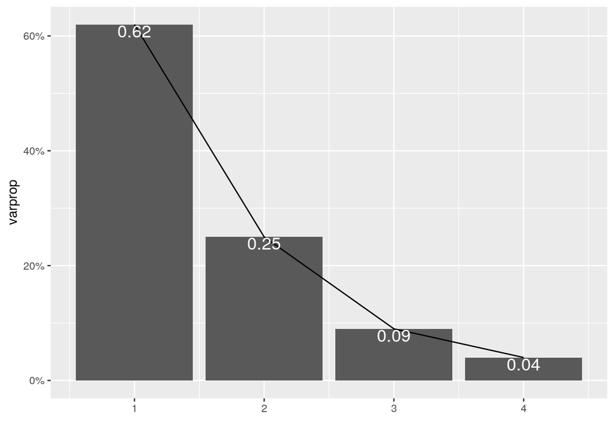

```r
varprop = round(eigval/sum(eigval), 2)  #proportion of var explained by each PC

ggplot() + geom_bar(aes(y = varprop, x = 1:4), stat = "identity") +
    xlab("") + geom_path(aes(y = varprop, x = 1:4)) + geom_text(aes(x = 1:4,
    y = varprop, label = round(varprop, 2)), vjust = 1, col = "white",
    size = 5) + scale_y_continuous(breaks = seq(0, 0.6, 0.2),
    labels = scales::percent) + scale_x_continuous(breaks = 1:10)  # Pick PCs until cumulative proportion of variance is > 80%
```

```r
round(cumsum(eigval)/sum(eigval), 2)  # cumulative proportion of variance # keep the first 2
```

```
## Comp.1 Comp.2 Comp.3 Comp.4
##   0.62   0.87   0.96   1.00
```

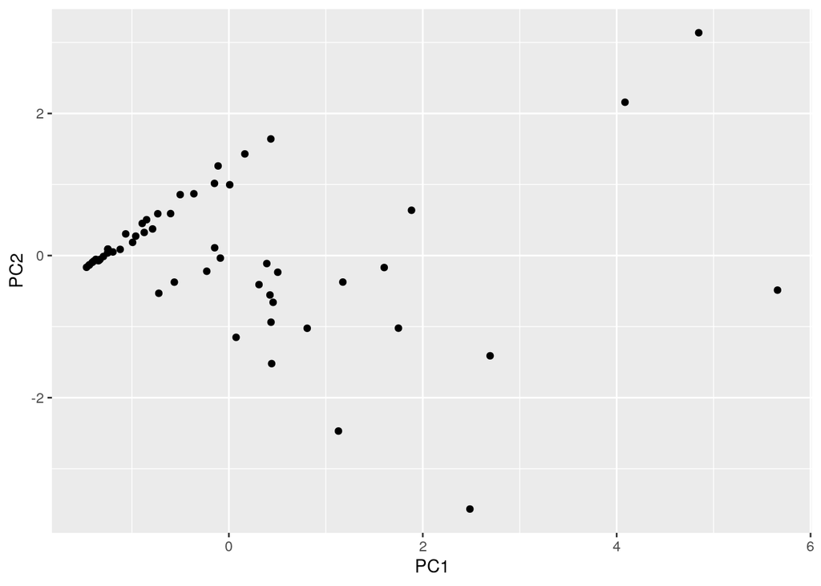

```r
# save the first two PCs in a dataframe
airlinedf <- data.frame(PC1 = airline_pca$scores[, 1], PC2 = airline_pca$scores[,
    2])

# plot them!
ggplot(airlinedf, aes(PC1, PC2)) + geom_point()
```

```r
## which are high/lo on PC1 and PC2?  highest on PC1
airline_pca$scores %>% as.data.frame %>% top_n(3, Comp.1)
```

```
##     Comp.1     Comp.2     Comp.3     Comp.4
## 1 5.659206 -0.4863315  0.6235095 -0.3990434
## 2 4.846416  3.1362744 -0.5909450 -0.4396995
## 3 4.086026  2.1581871  0.8483869  0.8569356
```

```r
# lowest on PC1
airline_pca$scores %>% as.data.frame %>% top_n(3, wt = desc(Comp.1))
```

```
##      Comp.1     Comp.2     Comp.3     Comp.4
## 1 -1.468409 -0.1650736 0.08573041 0.02446532
## 2 -1.443887 -0.1365631 0.11590394 0.04361211
## 3 -1.437094 -0.1286643 0.12426345 0.04891669
```

```r
# highest on PC2
airline_pca$scores %>% as.data.frame %>% top_n(3, wt = Comp.2)
```

```
##      Comp.1   Comp.2     Comp.3     Comp.4
## 1 4.8464158 3.136274 -0.5909450 -0.4396995
## 2 0.4329061 1.641424  0.5101882 -0.3043967
## 3 4.0860263 2.158187  0.8483869  0.8569356
```

```r
# lowest on PC2
airline_pca$scores %>% as.data.frame %>% top_n(3, wt = desc(Comp.2))
```

```
##      Comp.1    Comp.2     Comp.3     Comp.4
## 1 0.4413004 -1.520754 0.54102825 -0.2098620
## 2 1.1301990 -2.469713 0.02726629  0.1398239
## 3 2.4863657 -3.567250 1.37394603 -0.6764784
```

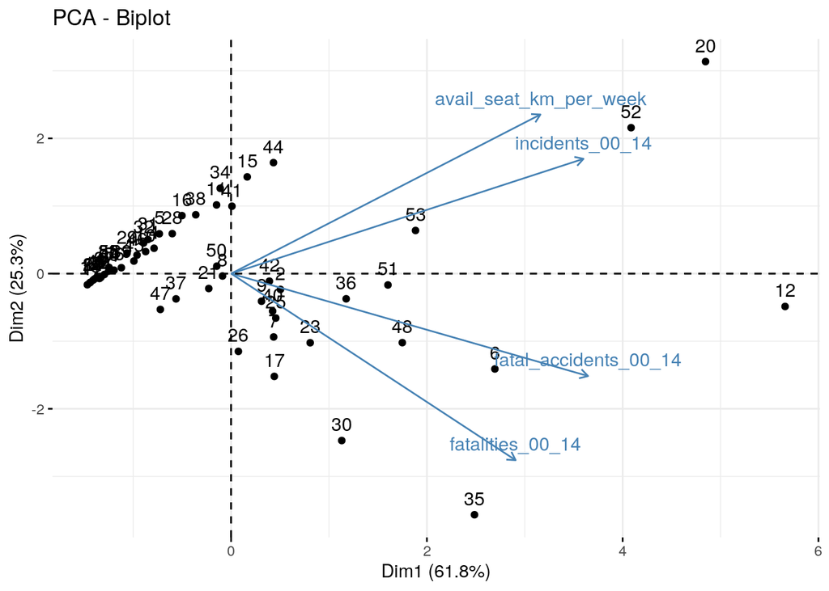

```r
## Make a nice byplot quickly:
library(factoextra)
fviz_pca_biplot(airline_pca)
```

### Linear Classifier

```r
# linear classifier code here

logistic_fit <- glm(incl_reg_subsidiaries == "TRUE" ~ avail_seat_km_per_week +
    incidents_00_14 + fatal_accidents_00_14 + fatalities_00_14,
    data = airline_safety1, family = "binomial")

prob_reg <- predict(logistic_fit, newdata = airline_safety1,
    type = "response")

class_diag(prob_reg, airline_safety1$incl_reg_subsidiaries, positive = "TRUE",
    cutoff = 0.5)
```

```
##            acc  sens  spec    ppv   f1   ba    auc
## Metrics 0.7679 0.375 0.925 0.6667 0.48 0.65 0.8344
```

```r
# cor matrix
cormat <- airline_safety1 %>% select_if(is.numeric) %>% cor(use = "pair")
cormat
```

```
##                        avail_seat_km_per_week incidents_00_14
## avail_seat_km_per_week              1.0000000       0.7259167
## incidents_00_14                     0.7259167       1.0000000
## fatal_accidents_00_14               0.3756729       0.5980711
## fatalities_00_14                    0.2284837       0.2820086
##                        fatal_accidents_00_14 fatalities_00_14
## avail_seat_km_per_week             0.3756729        0.2284837
## incidents_00_14                    0.5980711        0.2820086
## fatal_accidents_00_14              1.0000000        0.6958642
## fatalities_00_14                   0.6958642        1.0000000
```

```r
# cross-validation of linear classifier here

set.seed(322)
k = 10

data <- sample_frac(airline_safety1)  #randomly order rows
folds <- rep(1:k, length.out = nrow(data))  #create folds

diags <- NULL

i = 1
for (i in 1:k) {
    # create training and test sets
    train <- data[folds != i, ]
    test <- data[folds == i, ]
    truth <- test$incl_reg_subsidiaries

    fit <- glm(incl_reg_subsidiaries == "TRUE" ~ avail_seat_km_per_week +
        incidents_00_14 + fatal_accidents_00_14 + fatalities_00_14,
        data = train, family = "binomial")  ### SPECIFY THE LOGISTIC REGRESSION MODEL FIT TO THE TRAINING SET HERE

    # test model
    probs <- predict(fit, newdata = test, type = "response")  ### GET PREDICTIONS FROM THE TRAINED MODEL ON THE TEST SET HERE

    # get performance metrics for each fold
    diags <- rbind(diags, class_diag(probs, truth, positive = "TRUE"))
}

# average performance metrics across all folds
summarize_all(diags, mean)
```

```
##       acc sens  spec ppv  f1  ba     auc
## 1 0.73334  NaN 0.855 NaN NaN NaN 0.73139
```

```r
# Cor matrix
cormat <- airline_safety1 %>% select_if(is.numeric) %>% cor(use = "pair")
cormat
```

```
##                        avail_seat_km_per_week incidents_00_14
## avail_seat_km_per_week              1.0000000       0.7259167
## incidents_00_14                     0.7259167       1.0000000
## fatal_accidents_00_14               0.3756729       0.5980711
## fatalities_00_14                    0.2284837       0.2820086
##                        fatal_accidents_00_14 fatalities_00_14
## avail_seat_km_per_week             0.3756729        0.2284837
## incidents_00_14                    0.5980711        0.2820086
## fatal_accidents_00_14              1.0000000        0.6958642
## fatalities_00_14                   0.6958642        1.0000000
```

For the Linear Classifier (Logistic Regression Model), I attempted to predict the “TRUE” values for the binary variable: incl_reg_subsidiaries, which refers to if an airline included regional subsidiaries. For the predictor variables, I included the rest of the numeric variables in the dataset. Attempting to generate predicted score/probability for my original observations, the AUC score came out to be 0.8344. When performing 10-fold cross validation, I noticed a substantial decrease in the AUC score. It dropped approximately by 10%, to 0.73139, which shows signs of overfitting. It isn’t a crazy drop in performance, but still substantial enough to be able to say that when predicting on the original dataset, the model fit close to quirks with its boundaries made and thus, overfit with new data.

### Non-Parametric Classifier

```r
library(caret)
# non-parametric classifier code here

knn_fit <- knn3(factor(incl_reg_subsidiaries == "TRUE", levels = c("TRUE",
    "FALSE")) ~ avail_seat_km_per_week + incidents_00_14 + fatal_accidents_00_14 +
    fatalities_00_14, data = airline_safety1)

# your code here

prob_knn <- predict(knn_fit, airline_safety1)[, 1]

# prob_knn

class_diag(prob_knn, airline_safety1$incl_reg_subsidiaries, positive = "TRUE")
```

```
##            acc  sens  spec    ppv     f1   ba    auc
## Metrics 0.8036 0.625 0.875 0.6667 0.6452 0.75 0.8727
```

```r
# cross-validation of np classifier here

set.seed(322)
k = 10

data <- sample_frac(airline_safety1)  #randomly order rows
folds <- rep(1:k, length.out = nrow(data))  #create folds

diags <- NULL

i = 1
for (i in 1:k) {
    # create training and test sets
    train <- data[folds != i, ]
    test <- data[folds == i, ]
    truth <- test$incl_reg_subsidiaries

    # train model
    fit <- knn3(factor(incl_reg_subsidiaries == "TRUE", levels = c("TRUE",
        "FALSE")) ~ avail_seat_km_per_week + incidents_00_14 +
        fatal_accidents_00_14 + fatalities_00_14, data = train)  ### SPECIFY THE KNN MODEL FIT TO THE TRAINING SET HERE

    # test model
    probs <- predict(fit, newdata = test)[, 1]  ### GET PREDICTIONS FROM THE TRAINED MODEL ON THE TEST SET HERE

    # get performance metrics for each fold
    diags <- rbind(diags, class_diag(probs, truth, positive = "TRUE"))
}

# average performance metrics across all folds
summarize_all(diags, mean)
```

```
##       acc sens    spec ppv  f1  ba     auc
## 1 0.77334  NaN 0.90167 NaN NaN NaN 0.66125
```

### Regression/Numeric Prediction

```r
# regression model code here

fit <- lm(fatalities_00_14 ~ incidents_00_14 + fatal_accidents_00_14,
    data = airline_safety1)
yhat <- predict(fit)  #predicted incidents_00_14

mean((airline_safety1$fatalities_00_14 - yhat)^2)  #mean squared error (MSE)
```

```
## [1] 5937.666
```

```r
# cross-validation of regression model here

set.seed(1234)
k = 5  #choose number of folds

data <- airline_safety1[sample(nrow(airline_safety1)), ]  #randomly order rows
folds <- cut(seq(1:nrow(airline_safety1)), breaks = k, labels = F)  #create folds

diags <- NULL
for (i in 1:k) {
    train <- data[folds != i, ]
    test <- data[folds == i, ]

    ## Fit linear regression model to training set
    fit <- lm(fatalities_00_14 ~ incidents_00_14 + fatal_accidents_00_14,
        data = train)

    ## Get predictions/y-hats on test set (fold i)
    yhat <- predict(fit, newdata = test)

    ## Compute prediction error (MSE) for fold i
    diags <- mean((test$fatalities_00_14 - yhat)^2)
}

mean(diags)  ## get average MSE across all folds (much higher error)!
```

```
## [1] 20856.34
```

Fitting the Linear Regression Model to the entire dataset, I chose to predict the numeric variable: fatalities_00_14 which assesses the number of fatalities from 2000 to 2014, from two other numeric predictor variables: incidents_00_14 and fatal_accidents_00_14. These three variables really make up the bulk of my dataset, and 3 of the 4 numeric variables, the one other being the available seat km per week amount. There was such a huge contrast between this variable to the 3 chosen numeric variables for this model, that I decided to leave it out in order to produce cleaner and more understandable results for myself. After fitting the model, the reported MSE score for the dataset was 5937.666. This shows how close the regression line is to the data points, so the distances from the points to the line or errors amounted to the square root of 5937.666, which equals about 77.056. When performing 5-fold cross-validation, the reported average MSE score was 20856.34. This definitely shows that the model overfit on the overall dataset, as the MSE score increased by a huge amount from 5937.666 to 20856.34, equaling to about 3.5 times the original score.

### Python

```r
library(reticulate)
use_python("/usr/bin/python3")
```

```python
# python code here

#print(r.airline_safety1)
airline_py = r.airline_safety1

# Max number of fatalaties
print(r.airline_safety1.fatalities_00_14.max())

# Top 5 airlines with the most fatalities from the years 2000 - 2014
```

```
## 537
```

```python
print(r.airline_safety1.filter(["airline", "fatalities_00_14"]).sort_values(by="fatalities_00_14",
ascending=False).head(5))
```

```
##               airline  fatalities_00_14
## 34  Malaysia Airlines               537
## 11           American               416
## 5          Air France               337
## 29      Kenya Airways               283
## 16     China Airlines               225
```

```r
# min 10: incidents with airline name
py$airline_py %>% arrange(incidents_00_14) %>% select(airline,
    incidents_00_14) %>% head(10)
```

```
##                  airline incidents_00_14
## 1             Aer Lingus               0
## 2                Avianca               0
## 3                 Condor               0
## 4                   COPA               0
## 5                Finnair               0
## 6         Japan Airlines               0
## 7           LAN Airlines               0
## 8     TAP - Air Portugal               0
## 9        Virgin Atlantic               0
## 10 Aerolineas Argentinas               1
```

```r
# max 10: incidents with airline name
py$airline_py %>% arrange(desc(incidents_00_14)) %>% select(airline,
    incidents_00_14) %>% head(10)
```

```
##                      airline incidents_00_14
## 1          Delta / Northwest              24
## 2                   American              17
## 3       United / Continental              14
## 4              Saudi Arabian              11
## 5  US Airways / America West              11
## 6     Pakistan International              10
## 7         Southwest Airlines               8
## 8           Turkish Airlines               8
## 9         All Nippon Airways               7
## 10                       TAM               7
```